# Nanofish: AChE activity

# Set up environment

## Load libraries

## Load functions

## Load data

### Adjust classes and transformations

```
'data.frame':   467 obs. of  30 variables:
 $ StudyID             : Factor w/ 59 levels "2","3","4","5",..: 40 40 50 50 50 50 16 16 16 7 ...
 $ StudyCluster        : Factor w/ 34 levels "1","2","3","5",..: 4 4 5 5 5 5 4 4 4 18 ...
 $ Study               : Factor w/ 59 levels "Ašmonaitė et al., 2020",..: 1 1 2 2 2 2 3 3 3 4 ...
 $ Year                : int  2020 2020 2018 2018 2018 2018 2020 2020 2020 2019 ...
 $ EScluster           : Factor w/ 101 levels "1","2","3","4",..: 1 1 2 2 2 2 3 3 3 4 ...
 $ AdministrationRoute : Factor w/ 6 levels "Food","Injection",..: 1 1 4 4 4 4 1 1 1 4 ...
 $ Concentration_mg_L  : num  NA NA 0.26 0.69 0.26 0.69 NA NA NA 20 ...
 $ ParticleMaterial    : Factor w/ 6 levels "Aminoplast","PE",..: 5 2 1 1 1 1 2 2 2 5 ...
 $ Species             : Factor w/ 20 levels "Argyrosomus regius",..: 9 9 8 8 8 8 9 9 9 7 ...
 $ ParticleShape       : Factor w/ 4 levels "Irregular","Sphere",..: 2 2 2 2 2 2 2 2 2 2 ...
 $ Sex                 : Factor w/ 4 levels "F","F:M","M",..: 4 4 NA NA NA NA 4 4 4 NA ...
 $ DevelopmentalStage  : Factor w/ 5 levels "Embrio","Larva",..: 4 4 3 3 3 3 4 4 4 2 ...
 $ ExposureDurationCat : Factor w/ 3 levels "15 days +","5-15 days",..: 2 2 3 3 3 3 1 1 1 3 ...
 $ ExposureDurationDays: int  14 14 4 4 4 4 28 28 28 2 ...
```

[output cut: 16 more lines]

### Calculate Effect Size

```r
df_original <- metafor::escalc(measure = "SMD", n1i = n_treat, n2i = n_ctrl, m1i = mean_treat,
    m2i = mean_ctrl, sd1i = STD_treat, sd2i = STD_ctrl, data = df_original, vtype = "UB")
write.csv(df_original, file = "mvMetaAnalysis_SMDs.csv")
```

### Create variables

```r
outcome <- as.character(outcomeslist[[n_outcome]])

mRF <- list()  # random effects formula investigation models
mRE <- list()  # random effects multilevel models
mMR <- list()  # multilevel metaregression models

colormap <- c(Embrio = "khaki", Larva = "lightgreen", Juvenile = "lightskyblue",
    Adult = "salmon", Unclear = "plum", ExposureDurationDays = "cornflowerblue",
    ParticleSizeMean = "chartreuse4", Concentration_mg_L = "#fa0079ff", Aminoplast = "chocolate4",
    LDPE = "#2200faff", PE = "#0089faff", PET = "#00faedff", PLA = "#00fa29ff", PS = "#faf200ff",
    PVC = "#fa9a00ff", `Publication year` = "black", Variance = "navyblue")
```

### Select outcome data

```
[1] "AChE activity"
```

|  | StudyID | StudyCluster | Study | Year | EScluster | AdministrationRoute | Concentration_mg_L | ParticleMaterial | Species | ParticleShape | Sex | DevelopmentalStage | ExposureDurationCat | ExposureDurationDays | ParticleSizeRange | ParticleSizeMean | ParticleSizeCat | Outcome | OutcomeCategory | Test_or_Assay | OutcomeVariable | Group | n_of_groups | n_ctrl | mean_ctrl | STD_ctrl | n_treat | mean_treat | STD_treat | … |
| --- | --- | --- | --- | --- | --- | --- | --- | --- | --- | --- | --- | --- | --- | --- | --- | --- | --- | --- | --- | --- | --- | --- | --- | --- | --- | --- | --- | --- | --- | --- |
| 1 | 82 | 5 | Ašmonaitė et al., 2020 | 2020 | 1 | Food |  | PS | Gasterosteus aculeatus | Sphere | Unclear | Adult | 5-15 days | 14 | 250 | 250 | micro | AChE activity | Neurochemical outcomes | Neurotransmission | AChE activity | PS | 2 | 6 | 83.632 | 23.616 | 6 | 103.812 | 46.134 | … |
| 2 | 82 | 5 | Ašmonaitė et al., 2020 | 2020 | 1 | Food |  | PE | Gasterosteus aculeatus | Sphere | Unclear | Adult | 5-15 days | 14 | 212-250 | 231 | micro | AChE activity | Neurochemical outcomes | Neurotransmission | AChE activity | PE | 2 | 6 | 83.632 | 23.616 | 6 | 72.87 | 15.378 | … |
| 3 | 105 | 6 | Barboza et al., 2018a | 2018 | 2 | Water: Semi-static system | 0.26 | Aminoplast | Dicentrarchus labrax | Sphere |  | Juvenile | up to 96h | 4 | 1-5 | 3 | micro | AChE activity | Neurochemical outcomes | Neurotransmission | AChE activity | MPs-L (0.26) | 2 | 9 | 99.906 | 33.239 | 9 | 101.221 | 37.183 | … |
| 4 | 105 | 6 | Barboza et al., 2018a | 2018 | 2 | Water: Semi-static system | 0.69 | Aminoplast | Dicentrarchus labrax | Sphere |  | Juvenile | up to 96h | 4 | 1-5 | 3 | micro | AChE activity | Neurochemical outcomes | Neurotransmission | AChE activity | MPs-H (0.69) | 2 | 9 | 99.906 | 33.239 | 9 | 49.577 | 30.986 | … |
| 7 | 30 | 5 | Bour et al., 2020 | 2020 | 3 | Food |  | PE | Gasterosteus aculeatus | Sphere | Unclear | Adult | 15 days + | 28 | 27-32 | 29.5 | micro | AChE activity | Neurochemical outcomes | Neurotransmission | AChE activity | MPs | 1 | 12 | 45.508 | 36.306 | 13 | 28.96 | 8.95 | … |
| 23 | 53 | 10 | Campos et al., 2021 | 2021 | 5 | Water: Static system | 0.1 | PE | Argyrosomus regius | Irregular |  | Larva | up to 96h | 1 | 63-125 | 94 | micro | AChE activity | Neurochemical outcomes | Neurotransmission | AChE activity | 1 (black circle) | 3 | 5 | 170.531 | 6.481 | 5 | 147.633 | 14.475 | … |
| 24 | 53 | 10 | Campos et al., 2021 | 2021 | 5 | Water: Static system | 1 | PE | Argyrosomus regius | Irregular |  | Larva | up to 96h | 1 | 63-125 | 94 | micro | AChE activity | Neurochemical outcomes | Neurotransmission | AChE activity | 0.1 (black circle) | 3 | 5 | 170.531 | 6.481 | 5 | 146.28 | 13.395 | … |
| 25 | 53 | 10 | Campos et al., 2021 | 2021 | 5 | Water: Static system | 10 | PE | Argyrosomus regius | Irregular |  | Larva | up to 96h | 1 | 63-125 | 94 | micro | AChE activity | Neurochemical outcomes | Neurotransmission | AChE activity | 10 (black circle) | 3 | 5 | 170.531 | 6.481 | 5 | 134.589 | 5.185 | … |
| 31 | 28 | 1 | Chagas et al., 2021 | 2021 | 9 | Water: Semi-static system | 2.5 | PLA | Danio rerio | Irregular | F:M | Adult | 15 days + | 30 | 2.34 | 2.34 | micro | AChE activity | Neurochemical outcomes | Neurotransmission | AChE activity | BP I (2,5 mg/L) | 2 | 10 | 381.711 | 44.838 | 10 | 661.947 | 70.796 | … |
| 32 | 28 | 1 | Chagas et al., 2021 | 2021 | 9 | Water: Semi-static system | 5 | PLA | Danio rerio | Irregular | F:M | Adult | 15 days + | 30 | 2.34 | 2.34 | micro | AChE activity | Neurochemical outcomes | Neurotransmission | AChE activity | BP II (5 mg/L) | 2 | 10 | 381.711 | 44.838 | 10 | 631.858 | 68.437 | … |

[output cut: 73 more lines]

# Exploratory data analysis

## Funnel plot

> Before running any meta-analytic model, it is important to explore the meta-analytic dataset to search for potential outliers that could represent data extraction errors. (Nakagawa et al. 2022)

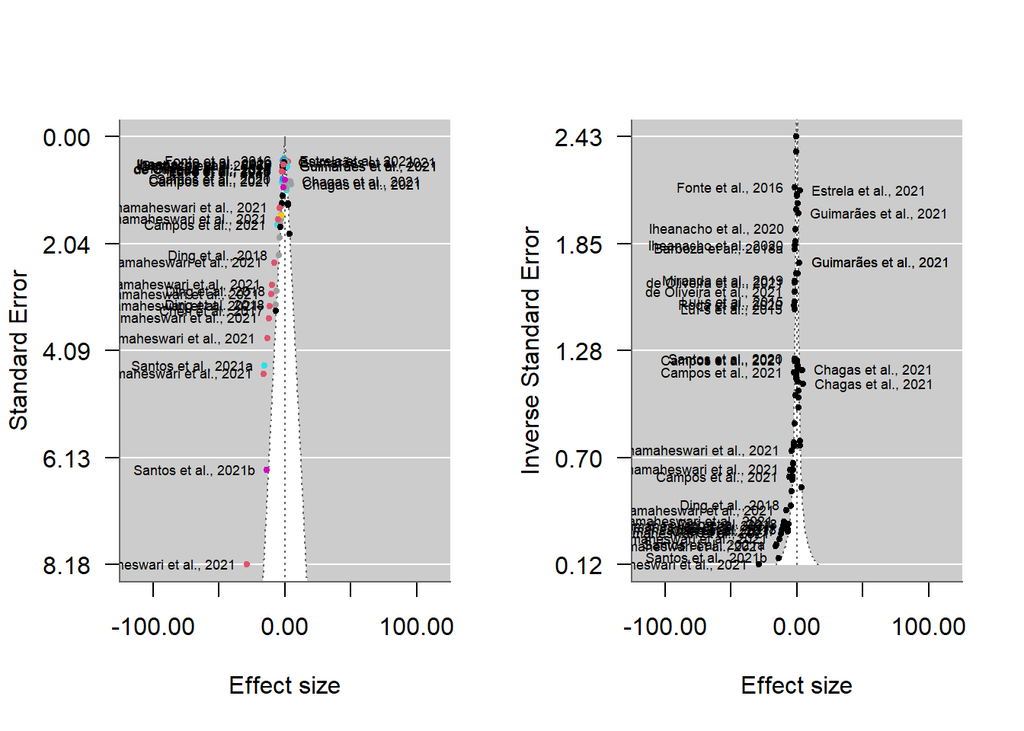

## Alluvial plot

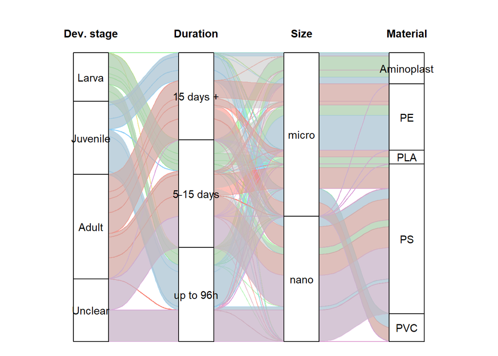

# Multilevel meta-analytic model

## Random effects formula desing

```
[1] "Considering number of studies: 25, number of ES clusters: 50 and number of independent observations of ES: 83, the random effects formula for AChE activity is: ~1 | Study/EScluster/ESid"
```

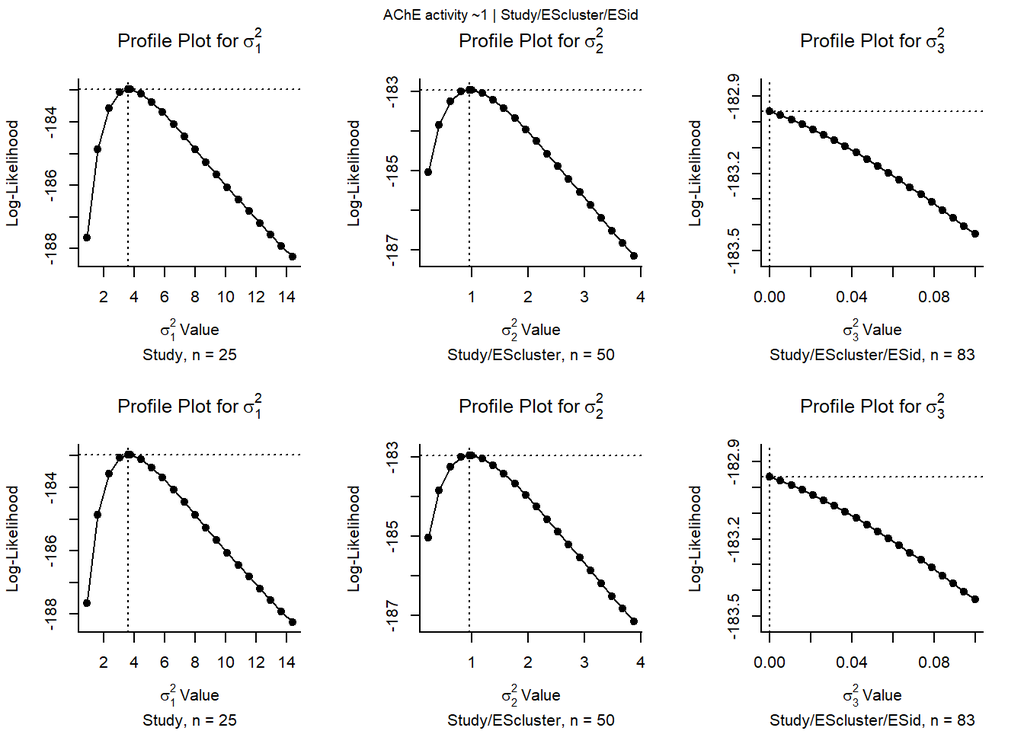

> A profile likelihood plot should show a single peak at the corresponding ML/REML estimate. If `refline=TRUE` (the default), the value of the parameter estimate is indicated by a dotted vertical line and its log-likelihood value by a dotted horizontal line. Hence, the intersection of these two lines should correspond to the peak (assuming that the model was fitted with ML/REML estimation).

> When profiling a variance component (or some other parameter that cannot be negative), the peak may be at zero (if this corresponds to the ML/REML estimate of the parameter). In this case, the profiled log-likelihood should be a monotonically decreasing function of the parameter. Similarly, when profiling a correlation component, the peak may be at -1 or +1.

> If the profiled log-likelihood has multiple peaks, this indicates that the likelihood surface is not unimodal. In such cases, the ML/REML estimate may correspond to a local optimum (when the intersection of the two dotted lines is not at the highest peak).

> If the profile is flat (over the entire parameter space or large portions of it), then this suggests that at least some of the parameters of the model are not identifiable (and the parameter estimates obtained are to some extent arbitrary). See Raue et al. (2009) for some further discussion of parameter identifiability and the use of profile likelihoods to check for this.

> The function checks whether any profiled log-likelihood value is actually larger than the log-likelihood of the fitted model (using a numerical tolerance of `lltol`). If so, a warning is issued as this might indicate that the optimizer did not identify the actual ML/REML estimate of the parameter profiled.[Viechtbauer (2022)](Viechtbauer 2010)

## Additional random effects factors

Study cluster, particle material and species as random effects term can further improve results?

```r
res <- vector("list", 3)

# with selected random effects formula only
mRF[["base"]] <- rma.mv(yi, vi, random = RE_formula, data = df, method = "ML")

# add Study Cluster (nested results were equal)
mRF[["StudyCluster"]] <- rma.mv(yi, vi, random = list(~1 | StudyCluster, RE_formula),
    data = df, method = "ML")

# add Particle Material
mRF[["ParticleMat"]] <- rma.mv(yi, vi, random = list(RE_formula, ~1 | ParticleMaterial),
    data = df, method = "ML")

# add Species
mRF[["Species"]] <- rma.mv(yi, vi, random = list(RE_formula, ~1 | Species), data = df,
    method = "ML")

t1 <- data.frame(sapply(mRF, fitstats))
rownames(t1) <- rownames(fitstats(mRF[[1]]))
names(t1) <- c("Nested", "+StudyCluster", "+ParticleMaterial", "+Species")

DT::datatable(t1)
```

|  | Nested | +StudyCluster | +ParticleMaterial | +Species |
| --- | --- | --- | --- | --- |
| logLik: | -182.9595241115274 | -181.7204655158556 | -182.9595241194445 | -182.9595241118245 |
| deviance: | 202.8933367146107 | 200.4152195232671 | 202.8933367304449 | 202.8933367152048 |
| AIC: | 373.9190482230547 | 373.4409310317112 | 375.919048238889 | 375.9190482236489 |
| BIC: | 383.5944106542411 | 385.5351340706942 | 388.013251277872 | 388.0132512626319 |
| AICc: | 374.4318687358752 | 374.220151810932 | 376.6982690181098 | 376.6982690028697 |

```r
res[[1]] <- anova(mRF[["base"]], mRF[["StudyCluster"]])
res[[2]] <- anova(mRF[["base"]], mRF[["ParticleMat"]])
res[[3]] <- anova(mRF[["base"]], mRF[["Species"]])

t2 <- data.frame(Comparison = c("+Study Cluster", "+ParticleMaterial", "+Species"),
    LRT = sapply(res, function(x) round(x$LRT, 2)), p_value = sapply(res, function(x) round(x$pval,
        3))  # p-value associado
)

DT::datatable(t2)
```

|  | Comparison | LRT | p_value |
| --- | --- | --- | --- |
| 1 | +Study Cluster | 2.48 | 0.115 |
| 2 | +ParticleMaterial | 0 | 1 |
| 3 | +Species | 0 | 1 |

## Main result: Multilevel model with $\rho = 0.5$ and robust variance estimate

```r
# Assumed correlation of rho = 0.5, except if there is only one ES by Study (no
# correlation)
if (nES == nSt) {
    VCVrho <- 0
    VCV <- df$vi
} else {
    VCVrho <- 0.5
    VCV <- vcalc(vi, cluster = interaction(df$EScluster, df$Study), obs = ESid, data = df,
        rho = VCVrho)
}

mname1 <- "ML"
mname2 <- paste0(mname1, "_RobVar")

mRE[[mname1]] <- rma.mv(yi, VCV, random = RE_formula, data = df, slab = Study, method = "REML",
    test = "t", dfs = "contain", level = 95)
mRE[[mname1]] <- additional_results(mRE[[mname1]])

mRE[[mname2]] <- robust(mRE[[mname1]], cluster = df$Study, clubSandwich = TRUE)

mRE[[mname2]] <- additional_results(mRE[[mname2]])

I2_ML_RobVar <- i2_ml(mRE[[mname2]])
# I2_ML_RobVar <- i2_ml(mRE[[mname2]], boot = 1000)

extract_report(mRE[[mname2]], outcome, RE_formula)
```

#### Diagnostics plots and results

```
Multivariate Meta-Analysis Model (k = 83; method: REML)

   logLik   Deviance        AIC        BIC       AICc
-176.3571   352.7141   360.7141   370.3410   361.2336

Variance Components:

            estim    sqrt  nlvls  fixed                factor
sigma^2.1  2.9366  1.7136     25     no                 Study
sigma^2.2  0.0711  0.2666     50     no       Study/EScluster
sigma^2.3  0.1403  0.3746     83     no  Study/EScluster/ESid

Test for Heterogeneity:
Q(df = 82) = 310.2298, p-val < .0001

Number of estimates:   83
Number of clusters:    25
Estimates per cluster: 0-18 (mean: 1.41, median: 0)

Model Results:

estimate      se¹     tval¹     df¹    pval¹    ci.lb¹   ci.ub¹
 -0.6736  0.3771   -1.7861   23.03   0.0873   -1.4537   0.1065   .

---
Signif. codes:  0 '***' 0.001 '**' 0.01 '*' 0.05 '.' 0.1 ' ' 1

1) results based on cluster-robust inference (var-cov estimator: CR2,
   approx t-test and confidence interval, df: Satterthwaite approx)
```

```
[1] 0.933 0.023 0.045
```

```
               I2_Total                I2_Study      I2_Study/EScluster
              83.957985               78.320302                1.895987
I2_Study/EScluster/ESid
               3.741696
```

```
$results
        % of total variance    I2
Level 1           16.042015   ---
Level 2            3.741696  3.74
Level 3            1.895987   1.9
Level 4           78.320302 78.32

$totalI2
[1] 83.95798

$plot
```

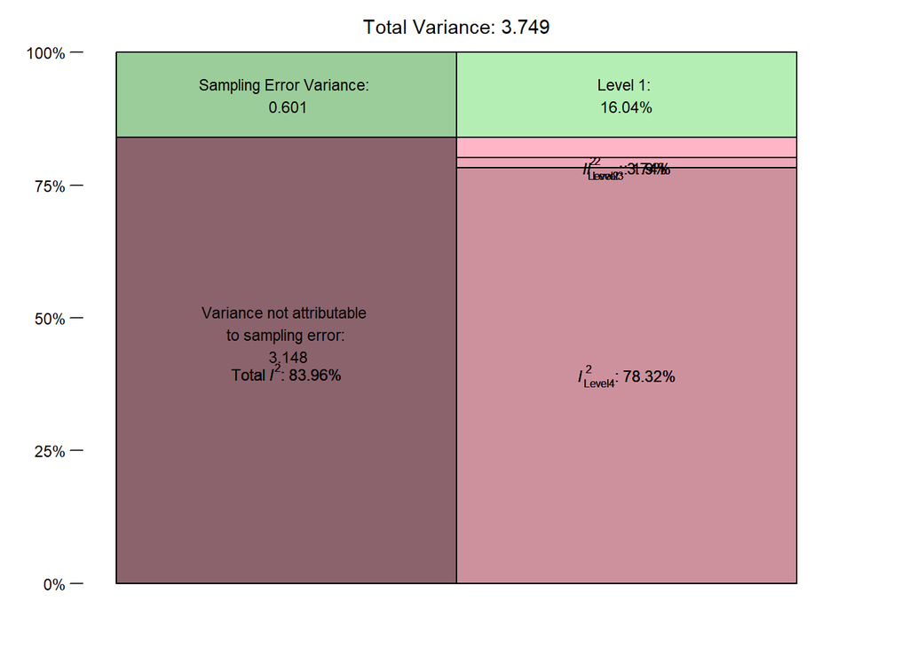

```
attr(,"class")
[1] "mlm.variance.distribution" "list"
```

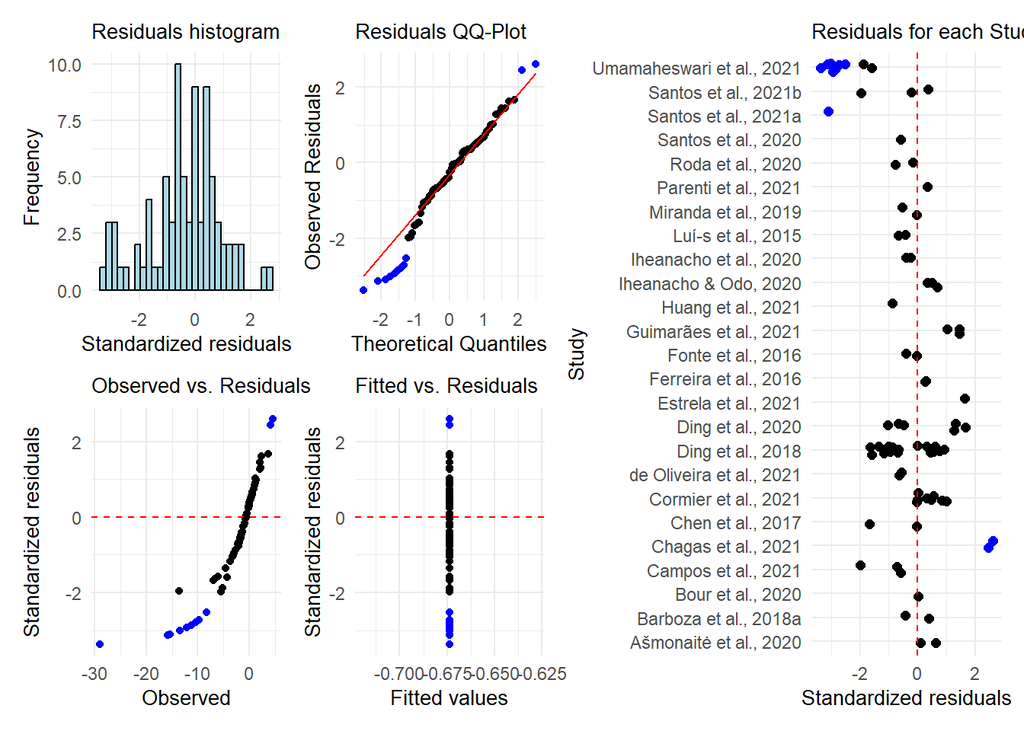

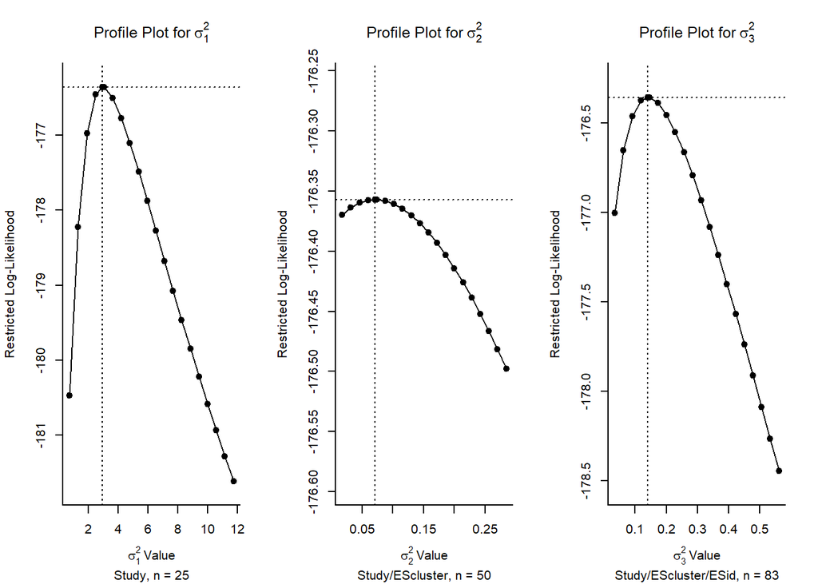

### Forest plot

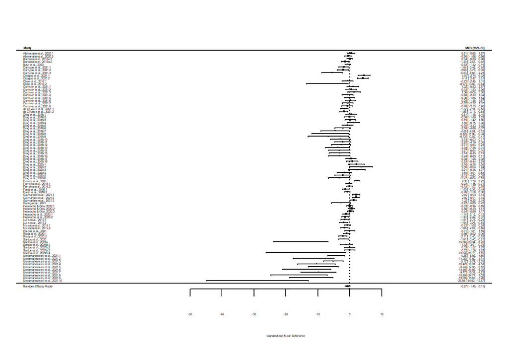

The meta-analysis comprised 83 comparisons from 50 control group clusters of 25 independent studies, so the random formula for AChE activity was ~1 | Study/EScluster/ESid.

No difference between treatment and control groups (ES = -0.673585 ± 0.3771363, CI95% = -1.453693 to 0.1065229, predicted interval -4.4256103 to 3.0784402), with high heterogeneity (i² = 83.96, Q = 310.2298484, p < 0.001 ) and variance explained by each component of $\sigma^2_{Study} = 2.94$, $\sigma^2_{EScluster} = 0.07$, $\sigma^2_{ESid} = 0.14$.

# Publication bias

> **Small-study effect:** when small studies (with small sample sizes) tend to report large effect sizes. (Yang et al. 2023)

> While the PET method works best when the true effect captured by β0β0 is **zero**, PEESE shows a better performance when the true effect is **not** zero. Stanley and Doucouliagos ([2014](https://bookdown.org/MathiasHarrer/Doing_Meta_Analysis_in_R/references.html#ref-stanley2014meta)) therefore proposed to combine both methods, in order to balance out their individual strengths. The resulting approach is the PET-PEESE method. PET-PEESE uses the intercept β0 of either PET or PEESE as the estimate of the corrected true effect.

> Whether PET or PEESE is used depends on the size of the intercept calculated by the PET method. When β0PET is significantly larger than zero in a one-sided test with α = 0.05, we use the intercept of PEESE as the true effect size estimate. If PET’s intercept is not significantly larger than zero, we remain with the PET estimate.

> In most implementations of regression models in *R*, it is conventional to test the significance of coefficients using a two-sided test (i.e. we test if a ββ weight significantly differs from zero, no matter the direction). To assume a one-sided test with α = 0.05, we already regard the intercept as significant when p < 0.1, and when the estimate of β0 is larger than zero<sup>38</sup>. (Harrer et al., n.d.)

> **Time-lag bias:** when statistically significant (“positive” results) tend to be published earlier than those with statistically non-significant findings (“negative” results), leading to a decline in reported effect sizes over time (i.e., a decline effect). (Yang et al. 2023)

> Given that high heterogeneity may invalidate publication bias test, it is best to account for the potential heterogeneity when testing publication bias. (Yang et al. 2023)

> PET-PEESE performs poorly in research areas where there are only a few studies, all studies use small samples, and where there is very high heterogeneity of results from study to study. Nonetheless, the statistical properties of conventional meta-analysis approaches are much worse than PET-PEESE under these same conditions.(Stanley 2017)

So, **better use meta-regression dataset**, but requires larger dataset to avoid possible convergence issues.

```r
# PET
df$ESSE <- sqrt(df$vi)  ## sampling error for ES

bias <- "PET"
mRE[[bias]] <- rma.mv(yi, VCV, random = RE_formula, mods = ~ESSE + Year, data = df,
    slab = Study, method = "REML", test = "t", dfs = "contain", level = 95)
mRE[[bias]] <- robust(mRE[[bias]], cluster = df$Study, clubSandwich = TRUE)
mRE[[bias]] <- additional_results(mRE[[bias]])
mRE[[bias]][["pi"]] <- predict(mRE[[bias]], newmods = c(0, mean(df$Year)), digits = 2)

# if estimate is significant, assumes a quadratic association between sampling
# error and effect sizes to avoid a downwardly biased estimate of the
# bias-corrected overall effect:

# PEESE
if (mRE[[bias]]$pval[1] < 0.1) {
    mname <- "PEESE"
    mRE[[mname]] <- rma.mv(yi, VCV, random = RE_formula, mods = ~vi + Year, data = df,
        slab = Study, method = "REML", test = "t", dfs = "contain", level = 95)
    mRE[[mname]] <- robust(mRE[[mname]], cluster = df$Study, clubSandwich = TRUE)
    mRE[[mname]] <- additional_results(mRE[[mname]])
    mRE[[mname]][["pi"]] <- predict(mRE[[mname]], newmods = c(0, mean(df$Year)),
        digits = 2)
    bias <- mname
}

# conditional estimate it it is significant there is no longer a single average
# effect (since the effect depends on the value of the moderator), so if we
# want to estimate the size of the effect, we have to specify a value for the
# moderator. One possibility is to estimate the ES based on the average of the
# moderator of all trials included in the meta-analysis.
```

#### Plots

```
[1] "PEESE"
```

```
Multivariate Meta-Analysis Model (k = 83; method: REML)

   logLik   Deviance        AIC        BIC       AICc
-140.5817   281.1635   293.1635   307.4556   294.3141

Variance Components:

            estim    sqrt  nlvls  fixed                factor
sigma^2.1  2.0432  1.4294     25     no                 Study
sigma^2.2  0.0000  0.0001     50     no       Study/EScluster
sigma^2.3  0.0708  0.2661     83     no  Study/EScluster/ESid

Test for Residual Heterogeneity:
QE(df = 80) = 214.4996, p-val < .0001

Number of estimates:   83
Number of clusters:    25
Estimates per cluster: 0-18 (mean: 1.41, median: 0)

Test of Moderators (coefficients 2:3):¹
F(df1 = 2, df2 = 3.8) = 19.1230, p-val = 0.0104

Model Results:

          estimate        se¹     tval¹    df¹    pval¹       ci.lb¹     ci.ub¹
intrcpt  -346.9522  291.6791   -1.1895   6.26   0.2774   -1053.6582   359.7538
vi         -0.5699    0.0821   -6.9413   2.29   0.0139      -0.8839    -0.2560
Year        0.1717    0.1446    1.1877   6.26   0.2780      -0.1784     0.5219

intrcpt
vi       *
Year

---
Signif. codes:  0 '***' 0.001 '**' 0.01 '*' 0.05 '.' 0.1 ' ' 1

1) results based on cluster-robust inference (var-cov estimator: CR2,
   approx t/F-tests and confidence intervals, df: Satterthwaite approx)
```

```
  pred   se ci.lb ci.ub pi.lb pi.ub
 -0.18 0.34 -0.89  0.53 -3.28  2.92
```

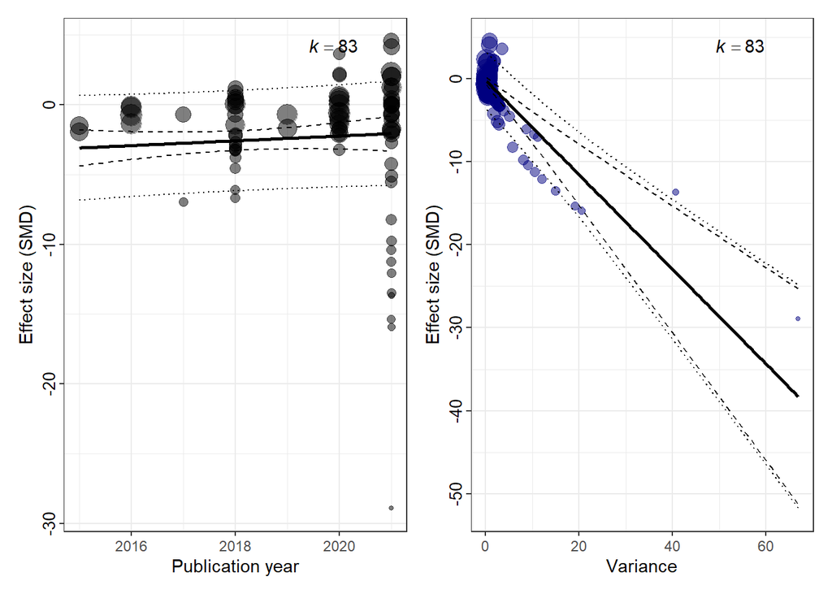

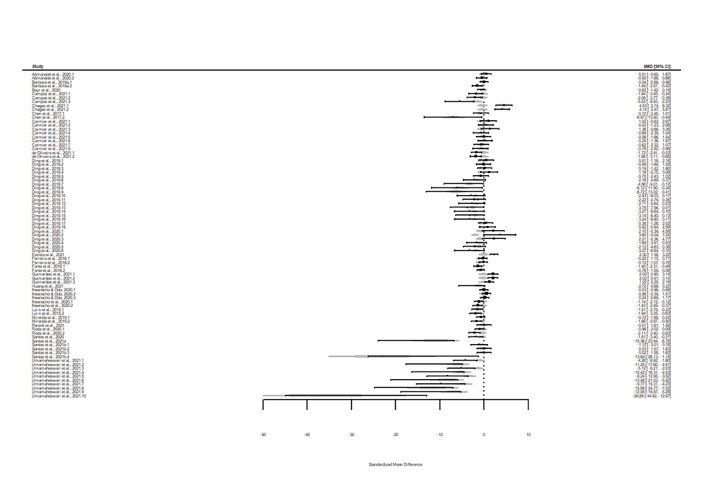

**Small-study effect** The regression slope of the extended Egger’s regression is $\sqrt{SMDSE} = -0.5699375$ is it statistically different from zero?`

If p<0.050: Smaller studies (with larger sampling error) have larger effect sizes –> small-study effect exists in this dataset. Data is assymmetrically distributed in the funnel plot.

If p>=0.050 no small-study effect exists in this dataset. Smaller studies (with larger sampling error) do not have larger effect sizes –> no small-study effect exists in this dataset. Data is symmetrically distributed in the funnel plot.

If p<0.050: studies with statistically significant findings tend to be published earlier than these with “negative” results, i.e. time-lag bias exists in this dataset

If p>=0.050: studies with statistically significant findings **do not** tend to be published earlier than these with “negative” results, i.e. no time-lag bias exists in this dataset

### Sensitivity analysis: publication bias with adapted SE

> Egger’s regression and its variants suffer from low power and poor performance when there are fewer than 20 effect sizes, or when the overall effect is large. (Nakagawa et al. 2022)

> Instead of the sample size (n1 + n2), however, for a meta-analysis of SMD or lnRR, we propose using the ‘effective sample size’ because it accounts for unbalanced sampling (cf. Stanley, 2005).(Nakagawa et al. 2022)

```r
# calculate modified SE based on effective sample size
df$ess_vi <- with(df, sqrt((n_treat + n_ctrl)/(n_treat * n_ctrl)))
df$ess_SE <- sqrt(df$ess_vi)  ## sampling error for ES

# PET + year
bias2 <- "PET sensitivity"
mRE[[bias2]] <- rma.mv(yi, VCV, random = RE_formula, mods = ~ess_SE + Year, data = df,
    slab = Study, method = "REML", test = "t", dfs = "contain", level = 95)
mRE[[bias2]] <- robust(mRE[[bias2]], cluster = df$Study, clubSandwich = TRUE)
mRE[[bias2]] <- additional_results(mRE[[bias2]])
mRE[[bias2]][["pi"]] <- predict(mRE[[bias2]], newmods = c(0, mean(df$Year)), digits = 2)

# PEESE + year
if (mRE[[bias2]]$pval[1] < 0.1) {
    mname <- "PEESE sensitivity"
    mRE[[mname]] <- rma.mv(yi, VCV, random = RE_formula, mods = ~ess_vi + Year, data = df,
        slab = Study, method = "REML", test = "t", dfs = "contain", level = 95)
    mRE[[mname]] <- robust(mRE[[mname]], cluster = df$Study, clubSandwich = TRUE)
    mRE[[mname]] <- additional_results(mRE[[mname]])
    mRE[[mname]][["pi"]] <- predict(mRE[[mname]], newmods = c(0, mean(df$Year)),
        digits = 2)
    bias2 <- mname
}
```

If the results are the same, indicates the robustness of the small-study test.

#### Plots

```r
print(bias2)
```

```
[1] "PET sensitivity"
```

```r
summary(mRE[[bias2]])
```

```
Multivariate Meta-Analysis Model (k = 83; method: REML)

   logLik   Deviance        AIC        BIC       AICc
-171.2555   342.5110   354.5110   368.8031   355.6617

Variance Components:

            estim    sqrt  nlvls  fixed                factor
sigma^2.1  3.0529  1.7473     25     no                 Study
sigma^2.2  0.0519  0.2279     50     no       Study/EScluster
sigma^2.3  0.1456  0.3816     83     no  Study/EScluster/ESid

Test for Residual Heterogeneity:
QE(df = 80) = 292.6961, p-val < .0001

Number of estimates:   83
Number of clusters:    25
Estimates per cluster: 0-18 (mean: 1.41, median: 0)

Test of Moderators (coefficients 2:3):¹
F(df1 = 2, df2 = 8.59) = 1.0105, p-val = 0.4035

Model Results:

          estimate        se¹     tval¹    df¹    pval¹       ci.lb¹     ci.ub¹
intrcpt  -204.5372  365.1026   -0.5602   6.48   0.5942   -1082.2116   673.1372
ess_SE     -4.9132    3.2717   -1.5017     12   0.1590     -12.0416     2.2153
Year        0.1028    0.1814    0.5666    6.5   0.5900      -0.3329     0.5385

intrcpt
ess_SE
Year

---
Signif. codes:  0 '***' 0.001 '**' 0.01 '*' 0.05 '.' 0.1 ' ' 1

1) results based on cluster-robust inference (var-cov estimator: CR2,
   approx t/F-tests and confidence intervals, df: Satterthwaite approx)
```

```r
mRE[[bias2]][["pi"]]
```

```
 pred   se ci.lb ci.ub pi.lb pi.ub
 3.05 2.57 -2.52  8.62 -3.75  9.85
```

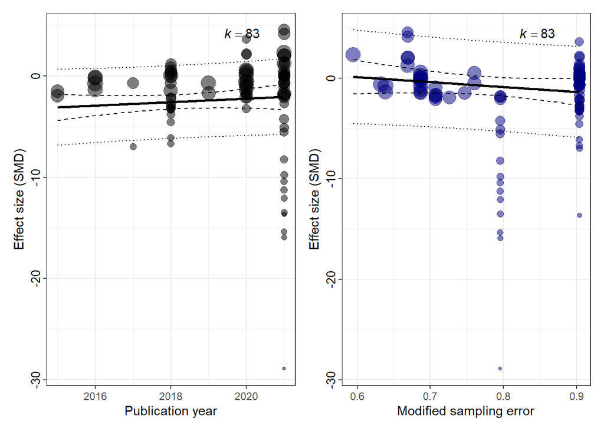

```r
plot_timelagbias <- bubble_plot(mRE[[bias]], mod = "Year", group = "Study", xlab = "Publication year",
    ylab = "Effect size (SMD)", legend.pos = "none", colorby = "Publication year",
    colormap = colormap)

if (mRE[["PET sensitivity"]]$pval[1] < 0.1) {
    plot_smallstudybias <- bubble_plot(mRE[[bias2]], mod = "ess_vi", group = "Study",
        xlab = "Modified sampling error variance", ylab = "Effect size (SMD)", legend.pos = "none",
        colorby = "Variance", colormap = colormap)
} else {
    plot_smallstudybias <- bubble_plot(mRE[[bias2]], mod = "ess_SE", group = "Study",
        xlab = "Modified sampling error", ylab = "Effect size (SMD)", legend.pos = "none",
        colorby = "Variance", colormap = colormap)
}

print(plot_timelagbias + plot_smallstudybias)
```

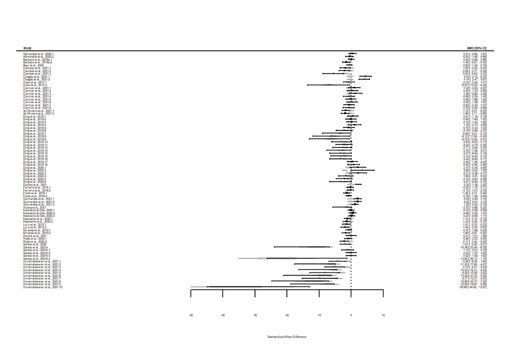

```r
forest(mRE[[bias]])
```

# Sensitivity

## Rho range

```r
if (VCVrho != 0) {

    rho_range <- c(0, 0.25, 0.75, 0.9)  # assume a range values of rho

    for (j in 1:length(rho_range)) {

        mname <- paste("rho", rho_range[j], sep = "_")

        VCV2 <- vcalc(vi, cluster = interaction(df$EScluster, df$Study), obs = ESid,
            data = df, rho = rho_range[j])

        mRE[[mname]] <- rma.mv(yi, VCV2, random = RE_formula, data = df, slab = Study,
            method = "REML", test = "t", dfs = "contain", level = 95)
        mRE[[mname]] <- robust(mRE[[mname]], cluster = df$Study, clubSandwich = TRUE)
        mRE[[mname]] <- additional_results(mRE[[mname]])
    }
}
```

##Leave Embryo or Unclear out + Rho range

```
[1] "rho 0.25 _drop_EmbryoUnclear"
[1] "rho 0.5 _drop_EmbryoUnclear"
[1] "rho 0.75 _drop_EmbryoUnclear"
[1] "rho 0.9 _drop_EmbryoUnclear"
```

## Leave one out + Rho range

```r
if (VCVrho != 0) {
    rho_range <- c(0.25, 0.5, 0.75, 0.9)
} else {
    rho_range <- 0
}

for (i in sort(unique(df$Study))) {

    df_temp <- df[df$Study != i, ]

    for (j in 1:length(rho_range)) {

        mname <- paste("rho", rho_range[j], "l1o", i, sep = "_")
        print(mname)
        VCV2 <- vcalc(vi, cluster = interaction(df_temp$EScluster, df_temp$Study),
            obs = ESid, data = df_temp, rho = rho_range[j])

        mRE[[mname]] <- rma.mv(yi, VCV2, random = RE_formula, data = df_temp, slab = Study,
            method = "REML", test = "t", dfs = "contain", level = 95)
        mRE[[mname]] <- robust(mRE[[mname]], cluster = df_temp$Study, clubSandwich = TRUE)
        mRE[[mname]] <- additional_results(mRE[[mname]])
    }
}
```

```
[1] "rho_0.25_l1o_Ašmonaitė et al., 2020"
[1] "rho_0.5_l1o_Ašmonaitė et al., 2020"
[1] "rho_0.75_l1o_Ašmonaitė et al., 2020"
[1] "rho_0.9_l1o_Ašmonaitė et al., 2020"
[1] "rho_0.25_l1o_Barboza et al., 2018a"
[1] "rho_0.5_l1o_Barboza et al., 2018a"
[1] "rho_0.75_l1o_Barboza et al., 2018a"
[1] "rho_0.9_l1o_Barboza et al., 2018a"
[1] "rho_0.25_l1o_Bour et al., 2020"
[1] "rho_0.5_l1o_Bour et al., 2020"
[1] "rho_0.75_l1o_Bour et al., 2020"
[1] "rho_0.9_l1o_Bour et al., 2020"
[1] "rho_0.25_l1o_Campos et al., 2021"
[1] "rho_0.5_l1o_Campos et al., 2021"
[1] "rho_0.75_l1o_Campos et al., 2021"
```

[output cut: 85 more lines]

# Tables

|  | n studies | n ES clusters | n ES | overall effect | standard error | p-value | Lower CI | Upper CI | Lower PI | Upper PI | Q | Q p-value | $I^2$$_{total}$ | $I^2$$_{Study}$ | $I^2$$_{EScluster}$ | $I^2$$_{ES}$ | $\sigma^2$$_{Study}$ | $\sigma^2$$_{EScluster}$ | $\sigma^2$$_{ES}$ |
| --- | --- | --- | --- | --- | --- | --- | --- | --- | --- | --- | --- | --- | --- | --- | --- | --- | --- | --- | --- |
| ML | 25 | 50 | 83 | -0.67 | 0.4 | 0.0862 | -1.45 | 0.10 | -4.42 | 3.07 | 310.23 | 0 | 83.96 | 78.32 | 1.90 | 3.74 | 2.94 | 0.07 | 0.14 |
| ML_RobVar | 25 | 50 | 83 | -0.67 | 0.4 | 0.0873 | -1.45 | 0.11 | -4.43 | 3.08 | 310.23 | 0 | 83.96 | 78.32 | 1.90 | 3.74 | 2.94 | 0.07 | 0.14 |
| PET | 25 | 50 | 83 | -557.80 | 249.8 | 0.0647 | -1161.55 | 45.95 | -1.30 | 5.00 | 209.58 | 0 | 77.56 | 75.83 | 0.00 | 1.72 | 2.03 | 0.00 | 0.05 |
| PEESE | 25 | 50 | 83 | -346.95 | 291.7 | 0.2774 | -1053.66 | 359.75 | -3.28 | 2.92 | 214.50 | 0 | 77.85 | 75.24 | 0.00 | 2.61 | 2.04 | 0.00 | 0.07 |
| PET sensitivity | 25 | 50 | 83 | -204.54 | 365.1 | 0.5942 | -1082.21 | 673.14 | -3.75 | 9.85 | 292.70 | 0 | 84.38 | 79.26 | 1.35 | 3.78 | 3.05 | 0.05 | 0.15 |
| rho_0 | 25 | 50 | 83 | -0.90 | 0.4 | 0.0554 | -1.83 | 0.02 | -5.53 | 3.72 | 408.59 | 0 | 88.86 | 70.70 | 18.16 | 0.00 | 3.82 | 0.98 | 0.00 |
| rho_0.25 | 25 | 50 | 83 | -0.79 | 0.4 | 0.0674 | -1.64 | 0.06 | -4.95 | 3.37 | 340.41 | 0 | 86.58 | 75.43 | 10.28 | 0.87 | 3.38 | 0.46 | 0.04 |
| rho_0.75 | 25 | 50 | 83 | -0.58 | 0.3 | 0.1053 | -1.29 | 0.13 | -4.01 | 2.85 | 321.27 | 0 | 81.37 | 70.73 | 0.00 | 10.64 | 2.28 | 0.00 | 0.34 |
| rho_0.9 | 25 | 50 | 83 | -0.52 | 0.3 | 0.1136 | -1.18 | 0.13 | -3.75 | 2.70 | 424.24 | 0 | 79.47 | 60.33 | 0.00 | 19.14 | 1.77 | 0.00 | 0.56 |
| rho 0.25 _drop_EmbryoUnclear | 24 | 44 | 65 | -0.76 | 0.4 | 0.0888 | -1.64 | 0.12 | -4.92 | 3.41 | 308.26 | 0 | 88.10 | 85.93 | 1.47 | 0.69 | 3.76 | 0.06 | 0.03 |
| rho 0.5 _drop_EmbryoUnclear | 24 | 44 | 65 | -0.67 | 0.4 | 0.1020 | -1.49 | 0.14 | -4.50 | 3.16 | 275.90 | 0 | 86.23 | 83.78 | 0.00 | 2.45 | 3.16 | 0.00 | 0.09 |
| rho 0.75 _drop_EmbryoUnclear | 24 | 44 | 65 | -0.55 | 0.4 | 0.1297 | -1.29 | 0.18 | -3.95 | 2.84 | 269.54 | 0 | 83.09 | 77.70 | 0.00 | 5.39 | 2.39 | 0.00 | 0.17 |
| rho 0.9 _drop_EmbryoUnclear | 24 | 44 | 65 | -0.45 | 0.3 | 0.1729 | -1.10 | 0.21 | -3.50 | 2.60 | 315.89 | 0 | 79.85 | 70.65 | 0.00 | 9.20 | 1.82 | 0.00 | 0.24 |
| rho_0.25_l1o_Ašmonaitė et al., 2020 | 24 | 49 | 81 | -0.83 | 0.4 | 0.0669 | -1.72 | 0.06 | -5.11 | 3.45 | 337.58 | 0 | 86.94 | 76.14 | 10.21 | 0.59 | 3.57 | 0.48 | 0.03 |
| rho_0.5_l1o_Ašmonaitė et al., 2020 | 24 | 49 | 81 | -0.71 | 0.4 | 0.0865 | -1.53 | 0.11 | -4.57 | 3.16 | 306.59 | 0 | 84.42 | 78.96 | 2.25 | 3.21 | 3.11 | 0.09 | 0.13 |
| rho_0.75_l1o_Ašmonaitė et al., 2020 | 24 | 49 | 81 | -0.61 | 0.4 | 0.1047 | -1.36 | 0.14 | -4.15 | 2.93 | 314.97 | 0 | 81.94 | 71.83 | 0.00 | 10.10 | 2.44 | 0.00 | 0.34 |
| rho_0.9_l1o_Ašmonaitė et al., 2020 | 24 | 49 | 81 | -0.55 | 0.3 | 0.1119 | -1.25 | 0.14 | -3.89 | 2.78 | 409.57 | 0 | 80.16 | 61.58 | 0.00 | 18.58 | 1.90 | 0.00 | 0.57 |
| rho_0.25_l1o_Barboza et al., 2018a | 24 | 49 | 81 | -0.80 | 0.4 | 0.0763 | -1.69 | 0.09 | -5.08 | 3.48 | 334.34 | 0 | 86.75 | 76.44 | 10.31 | 0.00 | 3.59 | 0.48 | 0.00 |
| rho_0.5_l1o_Barboza et al., 2018a | 24 | 49 | 81 | -0.67 | 0.4 | 0.1014 | -1.48 | 0.14 | -4.48 | 3.14 | 301.37 | 0 | 83.83 | 79.36 | 3.83 | 0.63 | 3.06 | 0.15 | 0.02 |
| rho_0.75_l1o_Barboza et al., 2018a | 24 | 49 | 81 | -0.56 | 0.4 | 0.1301 | -1.30 | 0.18 | -4.05 | 2.93 | 303.96 | 0 | 81.27 | 73.12 | 0.00 | 8.15 | 2.43 | 0.00 | 0.27 |
| rho_0.9_l1o_Barboza et al., 2018a | 24 | 49 | 81 | -0.51 | 0.3 | 0.1385 | -1.20 | 0.18 | -3.82 | 2.80 | 382.42 | 0 | 79.66 | 62.26 | 0.00 | 17.40 | 1.90 | 0.00 | 0.53 |
| rho_0.25_l1o_Bour et al., 2020 | 24 | 49 | 82 | -0.80 | 0.4 | 0.0760 | -1.70 | 0.09 | -5.11 | 3.50 | 340.19 | 0 | 86.92 | 76.02 | 10.04 | 0.85 | 3.61 | 0.48 | 0.04 |
| rho_0.5_l1o_Bour et al., 2020 | 24 | 49 | 82 | -0.68 | 0.4 | 0.0988 | -1.51 | 0.14 | -4.57 | 3.20 | 310.00 | 0 | 84.41 | 78.84 | 1.98 | 3.58 | 3.14 | 0.08 | 0.14 |
| rho_0.75_l1o_Bour et al., 2020 | 24 | 49 | 82 | -0.58 | 0.4 | 0.1201 | -1.33 | 0.17 | -4.14 | 2.97 | 320.90 | 0 | 81.86 | 71.64 | 0.00 | 10.22 | 2.45 | 0.00 | 0.35 |
| rho_0.9_l1o_Bour et al., 2020 | 24 | 49 | 82 | -0.53 | 0.3 | 0.1300 | -1.22 | 0.17 | -3.86 | 2.81 | 423.22 | 0 | 79.96 | 61.55 | 0.00 | 18.40 | 1.91 | 0.00 | 0.57 |
| rho_0.25_l1o_Campos et al., 2021 | 24 | 49 | 80 | -0.74 | 0.4 | 0.0962 | -1.62 | 0.14 | -4.97 | 3.50 | 329.08 | 0 | 87.06 | 76.12 | 10.11 | 0.83 | 3.49 | 0.46 | 0.04 |
| rho_0.5_l1o_Campos et al., 2021 | 24 | 49 | 80 | -0.63 | 0.4 | 0.1201 | -1.44 | 0.18 | -4.46 | 3.19 | 300.76 | 0 | 84.56 | 79.11 | 1.96 | 3.49 | 3.04 | 0.08 | 0.13 |
| rho_0.75_l1o_Campos et al., 2021 | 24 | 49 | 80 | -0.54 | 0.4 | 0.1410 | -1.28 | 0.19 | -4.03 | 2.94 | 311.28 | 0 | 81.98 | 72.38 | 0.00 | 9.60 | 2.38 | 0.00 | 0.32 |
| rho_0.9_l1o_Campos et al., 2021 | 24 | 49 | 80 | -0.48 | 0.3 | 0.1540 | -1.16 | 0.20 | -3.75 | 2.78 | 409.92 | 0 | 79.94 | 62.55 | 0.00 | 17.39 | 1.85 | 0.00 | 0.51 |
| rho_0.25_l1o_Chagas et al., 2021 | 24 | 49 | 81 | -0.95 | 0.4 | 0.0151 | -1.70 | -0.20 | -4.51 | 2.60 | 292.94 | 0 | 82.42 | 69.90 | 11.24 | 1.27 | 2.38 | 0.38 | 0.04 |

[output cut: 83 more lines]

|  | ML | ML_RobVar | PET | PEESE | PET.sensitivity | rho_0 | rho_0.25 | rho_0.75 | rho_0.9 | rho.0.25._drop_EmbryoUnclear | rho.0.5._drop_EmbryoUnclear | rho.0.75._drop_EmbryoUnclear | rho.0.9._drop_EmbryoUnclear | rho_0.25_l1o_Ašmonaitė.et.al...2020 | rho_0.5_l1o_Ašmonaitė.et.al...2020 | rho_0.75_l1o_Ašmonaitė.et.al...2020 | rho_0.9_l1o_Ašmonaitė.et.al...2020 | rho_0.25_l1o_Barboza.et.al...2018a | rho_0.5_l1o_Barboza.et.al...2018a | rho_0.75_l1o_Barboza.et.al...2018a | rho_0.9_l1o_Barboza.et.al...2018a | rho_0.25_l1o_Bour.et.al...2020 | rho_0.5_l1o_Bour.et.al...2020 | rho_0.75_l1o_Bour.et.al...2020 | rho_0.9_l1o_Bour.et.al...2020 | rho_0.25_l1o_Campos.et.al...2021 | rho_0.5_l1o_Campos.et.al...2021 | rho_0.75_l1o_Campos.et.al...2021 | rho_0.9_l1o_Campos.et.al...2021 | … |
| --- | --- | --- | --- | --- | --- | --- | --- | --- | --- | --- | --- | --- | --- | --- | --- | --- | --- | --- | --- | --- | --- | --- | --- | --- | --- | --- | --- | --- | --- | --- |
| logLik: | -176.357059136584 | -176.357059136584 | -132.4941066598358 | -140.581730584136 | -171.2554875063776 | -180.6496092780647 | -178.0436847023808 | -176.492319573645 | -177.4567589824481 | -139.8058452942773 | -138.3061744197711 | -138.4065085530381 | -139.7675886088605 | -174.8079190132938 | -173.2430586766004 | -173.5473057489114 | -174.5882387540676 | -173.0768349062404 | -171.6082154016253 | -172.7320348480788 | -174.0920795452606 | -176.3920372721179 | -174.8069357593744 | -175.0287546019303 | -176.0498430594032 | -171.3448670108727 | -169.4227155248407 | -169.2397122936524 | -170.090276395253 | … |
| deviance: | 352.714118273168 | 352.714118273168 | 264.9882133196717 | 281.1634611682721 | 342.5109750127551 | 361.2992185561294 | 356.0873694047616 | 352.98463914729 | 354.9135179648962 | 279.6116905885547 | 276.6123488395423 | 276.8130171060761 | 279.535177217721 | 349.6158380265875 | 346.4861173532009 | 347.0946114978227 | 349.1764775081351 | 346.1536698124807 | 343.2164308032507 | 345.4640696961576 | 348.1841590905212 | 352.7840745442358 | 349.6138715187487 | 350.0575092038606 | 352.0996861188063 | 342.6897340217453 | 338.8454310496815 | 338.4794245873047 | 340.180552790506 | … |
| AIC: | 360.714118273168 | 360.714118273168 | 276.9882133196717 | 293.1634611682721 | 354.5109750127551 | 369.2992185561294 | 364.0873694047616 | 360.98463914729 | 362.9135179648962 | 287.6116905885547 | 284.6123488395423 | 284.8130171060761 | 287.535177217721 | 357.6158380265875 | 354.4861173532009 | 355.0946114978227 | 357.1764775081351 | 354.1536698124807 | 351.2164308032507 | 353.4640696961576 | 356.1841590905212 | 360.7840745442358 | 357.6138715187487 | 358.0575092038606 | 360.0996861188063 | 350.6897340217453 | 346.8454310496815 | 346.4794245873047 | 348.180552790506 | … |
| BIC: | 370.340995262225 | 370.340995262225 | 291.2803731277149 | 307.4556209763153 | 368.8031348207984 | 378.9260955451864 | 373.7142463938186 | 370.6115161363469 | 372.5403949539532 | 296.2472229219933 | 293.247881172981 | 293.4485494395148 | 296.1707095511596 | 367.143944565283 | 364.0142238918964 | 364.6227180365182 | 366.7045840468306 | 363.6817763511762 | 360.7445373419462 | 362.9921762348531 | 365.7122656292167 | 370.3618711629256 | 367.1916681374385 | 367.6353058225504 | 369.6774827374961 | 360.1675254316134 | 356.3232224595495 | 355.9572159971728 | 357.6583442003741 | … |
| AICc: | 361.2335987926485 | 361.2335987926485 | 278.1388982511785 | 294.314146099779 | 355.661659944262 | 369.8186990756099 | 364.6068499242421 | 361.5041196667705 | 363.4329984843767 | 288.2896566902496 | 285.2903149412372 | 285.490983207771 | 288.2131433194158 | 358.1491713599209 | 355.0194506865342 | 355.6279448311561 | 357.7098108414685 | 354.6870031458141 | 351.749764136584 | 353.997403029491 | 356.7174924238546 | 361.3103903337095 | 358.1401873082224 | 358.5838249933343 | 360.62600190828 | 351.2302745622858 | 347.385971590222 | 347.0199651278452 | 348.7210933310465 | … |

# Influential cases

> Outliers and influential cases can actually reveal patterns that may lead to new insights about study characteristics that could be acting as potential moderators (Viechtbauer and Cheung 2010)

Cook’s distance: examine what effect the deletion of the ith study has on the fitted values of all k studies simultaneously (Viechtbauer and Cheung 2010)

DFBETAS: directly examine the influence of deleting the ith case on each individual parameter estimate (Viechtbauer and Cheung 2010)

So if a point has high Cook’s Distance, use DFBETAS to identify witch estimate is mainly influenced (only makes sense for meta regression).

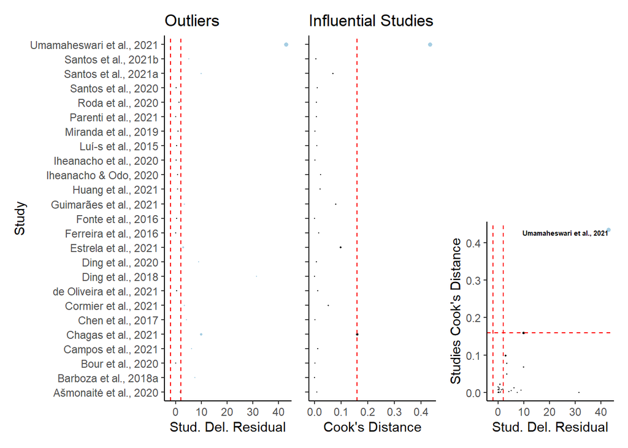

```r
influentialcases_plots(mRE, "ML_RobVar", "ML", 3)
```

# Multilevel meta-regression

SYRCLE PROTOCOL: Meta-regression will be used for outcomes with at least 10 experiments.

> The minimal number of studies or effect sizes required by a multilevel meta-regression remains unknown, albeit some simulation studies suggest that the estimates of model coefficients of a multilevel meta-regression are generally stable under various simulated situations.(Yang et al. 2023) … the complexity of parameterization of such a meta-regression requires a large dataset to make optimization algorithms free of convergence issues.(Yang et al. 2023)

## Model 1: Size, Duration, Development

```r
df_MR <- select(df, c("Year", "StudyID", "Study", "EScluster", "ESid", "DevelopmentalStage",
    "ExposureDurationDays", "ParticleSizeMean", "yi", "vi"))

mname1 <- "Base"
mname2 <- paste0(mname1, "_RobVar")

# are there differences between the different forms of DevelopmentalStage?
# mods_formula <- formula(~ ParticleSizeMean +
# ExposureDurationDays*DevelopmentalStage)

# at least one of the DevelopmentalStage levels is different than zero?
morethan1stages <- length(unique(df$DevelopmentalStage)) > 1
print(c("more than 1 developmental stage: ", morethan1stages))
```

```
[1] "more than 1 developmental stage: " "TRUE"
```

```r
if (morethan1stages) {
    mods_formula <- formula(~0 + ParticleSizeMean + ExposureDurationDays * DevelopmentalStage)
} else {
    # for Sensory-motor function
    mods_formula <- formula(~0 + ParticleSizeMean + ExposureDurationDays)
}

mMR[[mname1]] <- rma.mv(yi, VCV, random = RE_formula, mods = mods_formula, data = df_MR,
    slab = Study, method = "REML", test = "t", dfs = "contain", level = 95)  #it will only keep complete cases

nSt_MR <- mMR[[mname1]]$s.nlevels[1]  # number of studies
nEC_MR <- mMR[[mname1]]$s.nlevels[2]  # number of ESclusters/independent ES
nES_MR <- mMR[[mname1]]$s.nlevels[3]  # number of independent ES

if (length(mMR[[mname1]]$s.nlevels) == 3) {
    print(paste0("Number of studies: ", nSt_MR, ", number of ES clusters: ", nEC_MR,
        " and number of independent observations of ES: ", nES_MR))
} else {
    print(paste0("Number of studies: ", nSt_MR, " and number of independent observations of ES: ",
        nEC_MR))
}
```

```
[1] "Number of studies: 25, number of ES clusters: 50 and number of independent observations of ES: 83"
```

```r
mMR[[mname2]] <- robust(mMR[[mname1]], cluster = df_MR$Study, clubSandwich = TRUE,
    verbose = TRUE)
```

```
Error in Wald_testing(C_mat = constraints, beta = beta, vcov = vcov, test = test,  :
  Variance-covariance matrix of the contrast is not positive definite. The test cannot be computed.
```

```r
mMR[[mname2]][["i2"]] <- i2_ml(mMR[[mname2]])
mMR[[mname2]][["icc"]] <- round(mMR[[mname2]]$sigma2/sum(mMR[[mname2]]$sigma2), 3)

if (n_outcome != 10) {
    anova(mMR[[mname2]], btt = c("DevelopmentalStage", "ExposureDurationDays", "ParticleSizeMean"))
} else if (n_outcome == 10) {
    # for Sensory-motor function
    anova(mMR[[mname2]], btt = c("ExposureDurationDays", "ParticleSizeMean"))
}
```

```
                  spec coefs   Fval df1   df2   pval
1   DevelopmentalStage   3:9 0.0000   7 -0.22     NA
2 ExposureDurationDays 2,7:9 0.0115   4  0.49 0.9988
3     ParticleSizeMean     1 0.4613   1  1.51 0.5861
```

```r
m <- mMR[[mname2]]

summary(m)
```

```
Multivariate Meta-Analysis Model (k = 83; method: REML)

   logLik   Deviance        AIC        BIC       AICc
-159.1907   318.3814   342.3814   370.0302   347.4961

Variance Components:

            estim    sqrt  nlvls  fixed                factor
sigma^2.1  4.1892  2.0467     25     no                 Study
sigma^2.2  0.3152  0.5615     50     no       Study/EScluster
sigma^2.3  0.1606  0.4008     83     no  Study/EScluster/ESid

Test for Residual Heterogeneity:
QE(df = 74) = 297.8077, p-val < .0001

Number of estimates:   83
Number of clusters:    25
Estimates per cluster: 0-18 (mean: 1.41, median: 0)

Model Results:

                                                 estimate      se¹     tval¹
ParticleSizeMean                                  -0.0017  0.0025   -0.6792
ExposureDurationDays                               0.0153  0.0475    0.3216
DevelopmentalStageLarva                           -1.0115  0.9315   -1.0859
DevelopmentalStageJuvenile                        -0.3918  0.5415   -0.7236
DevelopmentalStageAdult                           -0.4999  1.5809   -0.3162
DevelopmentalStageUnclear                         -0.7504  8.6856   -0.0864
ExposureDurationDays:DevelopmentalStageLarva      -0.1095  0.2590   -0.4228
ExposureDurationDays:DevelopmentalStageJuvenile   -0.0087  0.0526   -0.1654
ExposureDurationDays:DevelopmentalStageAdult      -0.0169  0.0591   -0.2860
                                                   df¹    pval¹      ci.lb¹
ParticleSizeMean                                 1.51   0.5861     -0.0166
ExposureDurationDays                                1   0.8019     -0.5879
DevelopmentalStageLarva                          2.74   0.3638     -4.1447
DevelopmentalStageJuvenile                       6.82   0.4934     -1.6793
DevelopmentalStageAdult                          5.01   0.7646     -4.5613
DevelopmentalStageUnclear                           1   0.9451   -111.1111
ExposureDurationDays:DevelopmentalStageLarva     1.51   0.7248     -1.6494
ExposureDurationDays:DevelopmentalStageJuvenile  2.59   0.8807     -0.1922
ExposureDurationDays:DevelopmentalStageAdult     1.45   0.8104     -0.3912
                                                    ci.ub¹
ParticleSizeMean                                   0.0132
ExposureDurationDays                               0.6185
DevelopmentalStageLarva                            2.1217
DevelopmentalStageJuvenile                         0.8956
DevelopmentalStageAdult                            3.5614
DevelopmentalStageUnclear                        109.6102
ExposureDurationDays:DevelopmentalStageLarva       1.4304
ExposureDurationDays:DevelopmentalStageJuvenile    0.1748
ExposureDurationDays:DevelopmentalStageAdult       0.3574

---
Signif. codes:  0 '***' 0.001 '**' 0.01 '*' 0.05 '.' 0.1 ' ' 1

1) results based on cluster-robust inference (var-cov estimator: CR2,
   approx t/F-tests and confidence intervals, df: Satterthwaite approx)
```

```r
m$fit.stats
```

|  | ML | REML |
| --- | --- | --- |
| ll | -178.5266 | -159.1907 |
| dev | 204.8167 | 318.3814 |
| AIC | 381.0533 | 342.3814 |
| BIC | 410.0794 | 370.0302 |
| AICc | 385.5104 | 347.4961 |

#### Diagnostics plots

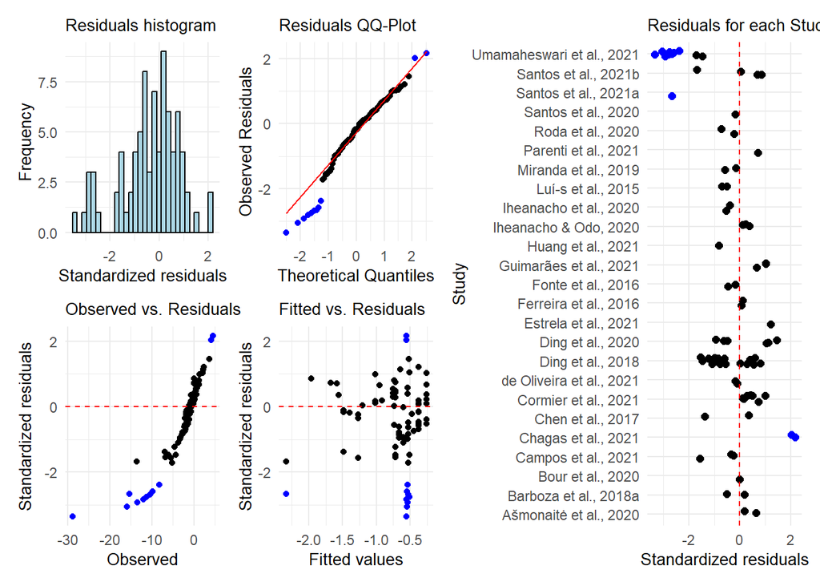

```r
diagnostic_plots(m)
```

#### Orchard plots

(Nakagawa et al. 2021)

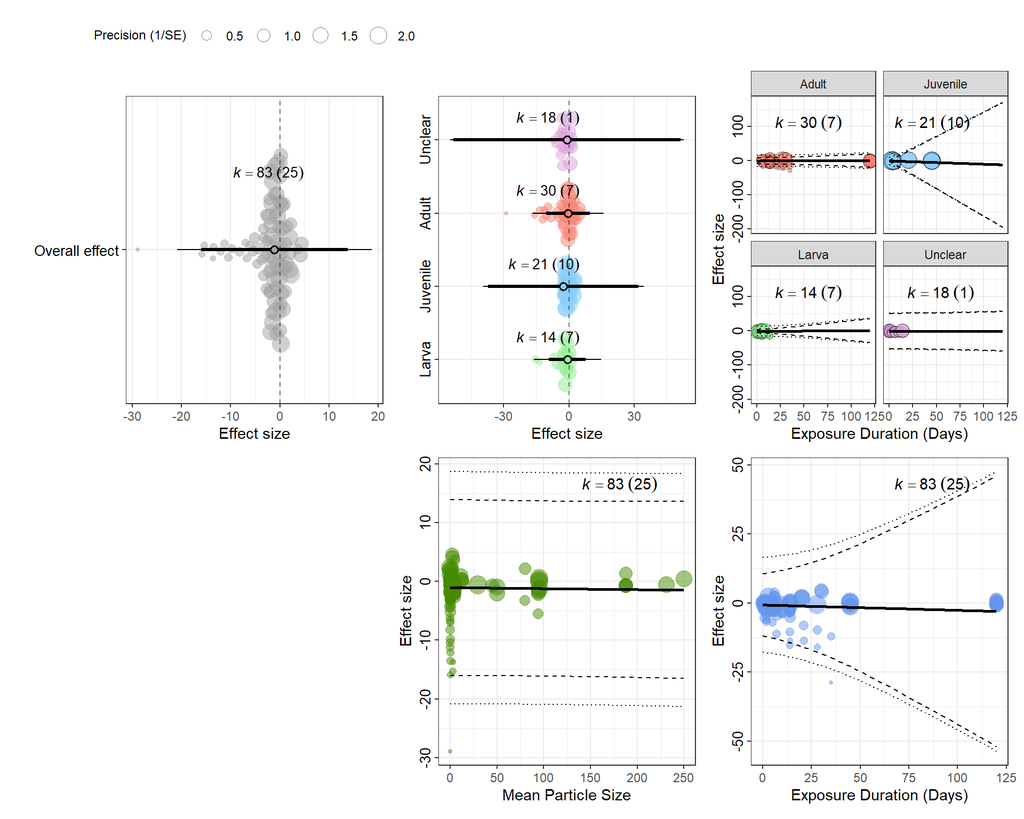

## Model 2: + Concentration

```r
morethan3concentrations <- length(unique(df$Concentration_mg_L)) > 3  #one can be NA
print(c("more than 3 concentrations: ", morethan3concentrations))
```

```
[1] "more than 3 concentrations: " "TRUE"
```

```r
if (morethan3concentrations) {

    df_MR <- select(df, c("Year", "StudyID", "Study", "EScluster", "ESid", "DevelopmentalStage",
        "ExposureDurationDays", "ParticleSizeMean", "Concentration_mg_L", "yi", "vi"))

    mname1 <- "Conc+"
    mname2 <- paste0(mname1, "_RobVar")

    if (n_outcome != 10) {
        mods_formula <- formula(~0 + ParticleSizeMean + Concentration_mg_L + ExposureDurationDays *
            DevelopmentalStage)
    } else if (n_outcome == 10) {
        # for Sensory-motor function for Sensory-motor function
        mods_formula <- formula(~0 + ParticleSizeMean + Concentration_mg_L + ExposureDurationDays)
    }

    mMR[[mname1]] <- rma.mv(yi, VCV, random = RE_formula, mods = mods_formula, data = df_MR,
        slab = Study, method = "REML", test = "t", dfs = "contain", level = 95)  #it will only keep complete cases

    nSt_MR <- mMR[[mname1]]$s.nlevels[1]  # number of studies
    nEC_MR <- mMR[[mname1]]$s.nlevels[2]  # number of ESclusters/independent ES
    nES_MR <- mMR[[mname1]]$s.nlevels[3]  # number of independent ES

    if (length(mMR[[mname1]]$s.nlevels) == 3) {
        print(paste0("Number of studies: ", nSt_MR, ", number of ES clusters: ",
            nEC_MR, " and number of independent observations of ES: ", nES_MR))
    } else {
        print(paste0("Number of studies: ", nSt_MR, " and number of independent observations of ES: ",
            nEC_MR))
    }

    mMR[[mname2]] <- robust(mMR[[mname1]], cluster = df_MR$Study, clubSandwich = TRUE,
        verbose = TRUE)

    mMR[[mname2]][["i2"]] <- i2_ml(mMR[[mname2]])
    mMR[[mname2]][["icc"]] <- round(mMR[[mname2]]$sigma2/sum(mMR[[mname2]]$sigma2),
        3)

    if (n_outcome != 10) {
        anova(mMR[[mname2]], btt = c("DevelopmentalStage", "ExposureDurationDays",
            "ParticleSizeMean", "Concentration_mg_L"))
    } else if (n_outcome == 10) {
        # for Sensory-motor function
        anova(mMR[[mname2]], btt = c("ExposureDurationDays", "ParticleSizeMean",
            "Concentration_mg_L"))
    }
    m <- mMR[[mname2]]

    summary(m)
    m$fit.stats
}
```

```
[1] "Number of studies: 20, number of ES clusters: 38 and number of independent observations of ES: 67"
```

|  | ML | REML |
| --- | --- | --- |
| ll | -154.4658 | -132.6031 |
| dev | 171.9637 | 265.2062 |
| AIC | 334.9316 | 291.2062 |
| BIC | 363.5926 | 317.7658 |
| AICc | 341.7996 | 299.6713 |

#### Diagnostics plots

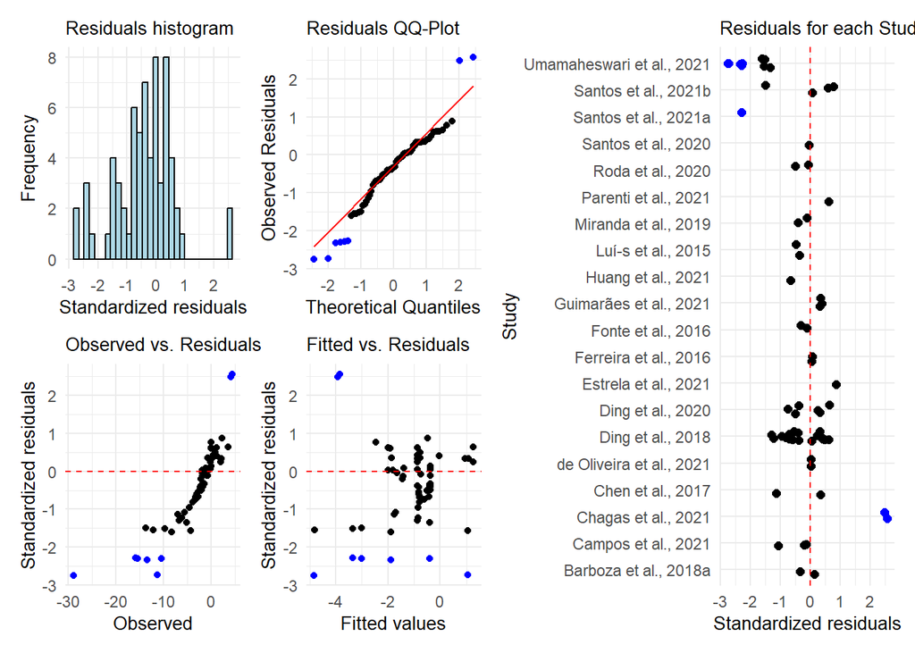

```r
if (morethan3concentrations) {
    diagnostic_plots(m)
}
```

#### Influential cases

[figure not shown]

```r
if (morethan3concentrations) {
    tryCatch({
        distance <- cooks.distance(m, cluster = df$Study)
        distance
    }, error = function(e) {
        message("Erro capturado: ", e$message)
    })
    tryCatch({
        influentialcases_plots(mMR, mname2, mname1, 0.01)
    }, error = function(e) {
        message("Erro capturado: ", e$message)
    })
}
```

```r
# measure residuals ic_distance <-cooks.distance(m, cluster=df$Study) Not
# available for robust rma: ########### ic_rstudent <- rstudent(mMR[[mname1]],
# 2, progbar=FALSE, cluster=df$Study, reestimate=TRUE) ic_dfbetas
# <-dfbetas(mMR[[mname1]], cluster=df$Study)
```

#### Orchard plots

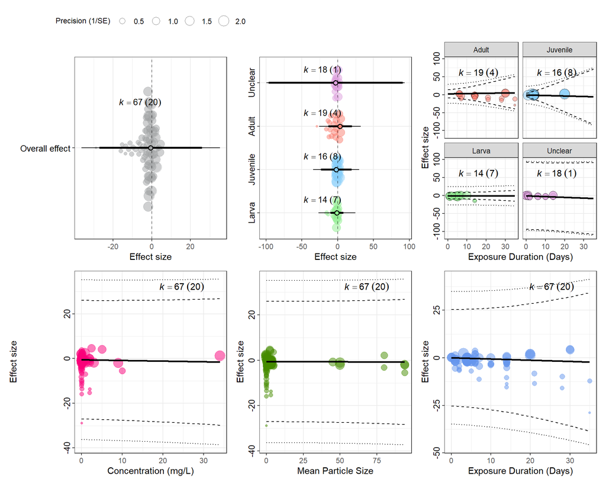

#### Influential cases

#### Orchard plots

# Referências

Harrer, Mathias, Pim Cuijpers, Toshi A. Furukawa, and David D. Ebert. n.d. *Chapter 9 Publication Bias | Doing Meta-Analysis in R*. https://bookdown.org/MathiasHarrer/Doing_Meta_Analysis_in_R/pub-bias.html.

Nakagawa, Shinichi, Malgorzata Lagisz, Michael D. Jennions, Julia Koricheva, Daniel W. A. Noble, Timothy H. Parker, Alfredo Sánchez-Tójar, Yefeng Yang, and Rose E. O’Dea. 2022. “Methods for Testing Publication Bias in Ecological and Evolutionary Meta-Analyses.” *Methods in Ecology and Evolution* 13 (1): 4–21. https://doi.org/10.1111/2041-210X.13724.

Nakagawa, Shinichi, Malgorzata Lagisz, Rose E. O’Dea, Joanna Rutkowska, Yefeng Yang, Daniel W. A. Noble, and Alistair M. Senior. 2021. “The Orchard Plot: Cultivating a Forest Plot for Use in Ecology, Evolution, and Beyond.” *Research Synthesis Methods* 12 (1): 4–12. https://doi.org/10.1002/jrsm.1424.

Stanley, T. D. 2017. “Limitations of PET-PEESE and Other Meta-Analysis Methods.” *Social Psychological and Personality Science* 8 (5): 581–91. https://doi.org/10.1177/1948550617693062.

Viechtbauer, Wolfgang. 2010. “Conducting Meta-Analyses in R with the Metafor Package.” *Journal of Statistical Software* 36 (August): 1–48. https://doi.org/10.18637/jss.v036.i03.

———. 2022. “Konstantopoulos (2011) [the Metafor Package].” https://www.metafor-project.org/doku.php/analyses:konstantopoulos2011.

Viechtbauer, Wolfgang, and Mike W.-L. Cheung. 2010. “Outlier and Influence Diagnostics for Meta-Analysis.” *Research Synthesis Methods* 1 (2): 112–25. https://doi.org/10.1002/jrsm.11.

Yang, Yefeng, Malcolm Macleod, Jinming Pan, Malgorzata Lagisz, and Shinichi Nakagawa. 2023. “Advanced Methods and Implementations for the Meta-Analyses of Animal Models: Current Practices and Future Recommendations.” *Neuroscience & Biobehavioral Reviews* 146 (March): 105016. https://doi.org/10.1016/j.neubiorev.2022.105016.